# ReproducibleResearch_CourseProject1

Laura Sandberg

9/8/2021

## Loading and preprocessing the data

```r
library(ggplot2)
library(dplyr)
activity <- read.csv("./activity.csv")

summary(activity)
```

```
##      steps                date          interval
##  Min.   :  0.00   2012-10-01:  288   Min.   :   0.0
##  1st Qu.:  0.00   2012-10-02:  288   1st Qu.: 588.8
##  Median :  0.00   2012-10-03:  288   Median :1177.5
##  Mean   : 37.38   2012-10-04:  288   Mean   :1177.5
##  3rd Qu.: 12.00   2012-10-05:  288   3rd Qu.:1766.2
##  Max.   :806.00   2012-10-06:  288   Max.   :2355.0
##  NA's   :2304     (Other)   :15840
```

## What is mean total number of steps taken per day?

1. Calculate the total number of steps taken per day
2. If you do not understand the difference between a histogram and a barplot, research the difference between them. Make a histogram of the total number of steps taken each day
3. Calculate and report the mean and median of the total number of steps taken per day

### Number of steps per day

```r
Total.steps <- aggregate(activity$steps, list(activity$date), FUN=sum)
colnames(Total.steps) <- c("date", "steps")
Total.steps
```

```
##          date steps
## 1  2012-10-01    NA
## 2  2012-10-02   126
## 3  2012-10-03 11352
## 4  2012-10-04 12116
## 5  2012-10-05 13294
## 6  2012-10-06 15420
## 7  2012-10-07 11015
## 8  2012-10-08    NA
## 9  2012-10-09 12811
## 10 2012-10-10  9900
## 11 2012-10-11 10304
## 12 2012-10-12 17382
## 13 2012-10-13 12426
## 14 2012-10-14 15098
```

[output cut: 47 more lines]

### Histogram of the total number of steps taken each day

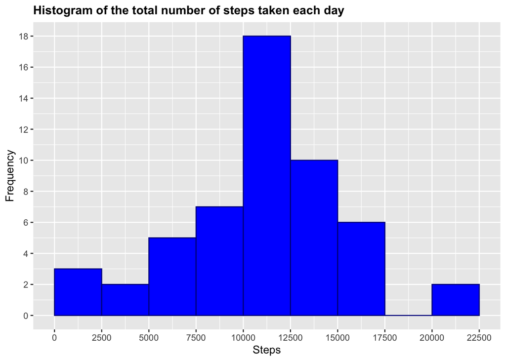

```r
ggplot(Total.steps, aes(steps)) +
  geom_histogram(boundary=0, binwidth=2500, col="darkblue", fill="blue") +
  ggtitle("Histogram of the total number of steps taken each day") +
  xlab("Steps") +
  ylab("Frequency") +
  theme(plot.title = element_text(face="bold", size=12)) +
  scale_x_continuous(breaks=seq(0,25000,2500)) +
  scale_y_continuous(breaks=seq(0,18,2))
```

### Mean and median of the total number of steps taken per day

```r
# Mean
mean(Total.steps$steps, na.rm=TRUE)
```

```
## [1] 10766.19
```

```r
# Median
median(Total.steps$steps, na.rm=TRUE)
```

```
## [1] 10765
```

## What is the average daily activity pattern?

1. Make a time series plot (i.e. type = “l” of the 5-minute interval (x-axis) and the average number of steps taken, averaged across all days (y-axis)
2. Which 5-minute interval, on average across all the days in the dataset, contains the maximum number of steps?

### Time series plot and the average number of steps taken

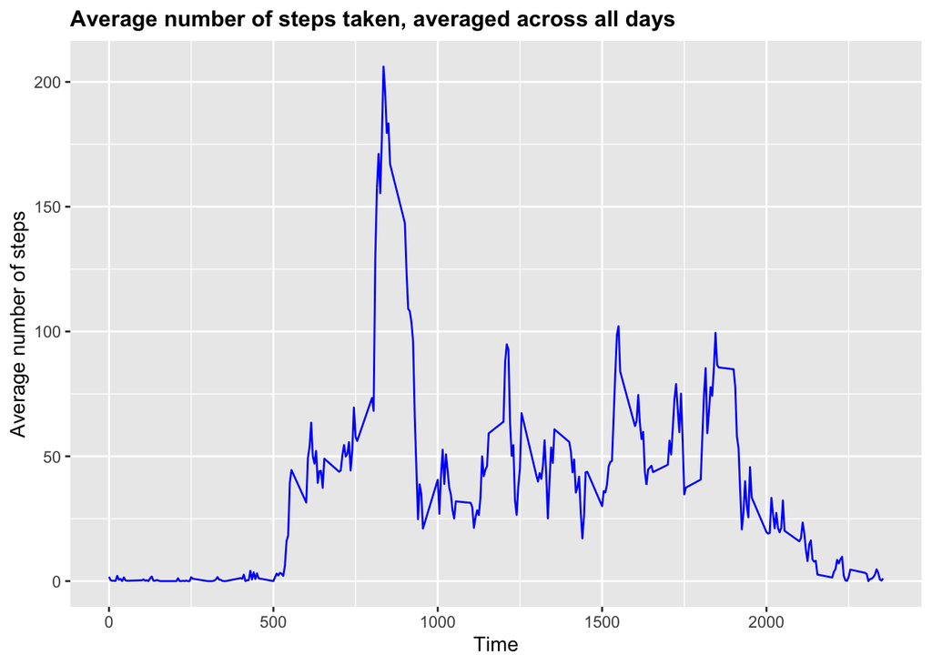

```r
Avg.steps <- aggregate(activity$steps, by=list(activity$interval), FUN=mean, na.rm=TRUE)
colnames(Avg.steps) <- c("interval", "mean")

ggplot(Avg.steps, aes(interval, mean)) +
  geom_line(col="blue")+
  ggtitle("Average number of steps taken, averaged across all days") +
  xlab("Time") +
  ylab("Average number of steps") +
  theme(plot.title = element_text(face="bold", size=12))
```

### 5-minute interval that contains the maximum number of steps

```r
Avg.steps %>%
  filter(
    mean == max(mean)
  )
```

```
##   interval     mean
## 1      835 206.1698
```

## Imputing missing values

1. Calculate and report the total number of missing values in the dataset (i.e. the total number of rows with NAs)
2. Devise a strategy for filling in all of the missing values in the dataset. The strategy does not need to be sophisticated. For example, you could use the mean/median for that day, or the mean for that 5-minute interval, etc.
3. Create a new dataset that is equal to the original dataset but with the missing data filled in.
4. Make a histogram of the total number of steps taken each day and Calculate and report the mean and median total number of steps taken per day. Do these values differ from the estimates from the first part of the assignment? What is the impact of imputing missing data on the estimates of the total daily number of steps?

### Total number of missing values in the dataset

```r
sum(is.na(activity$steps))
```

```
## [1] 2304
```

### Strategy for filling in all of the missing values

```r
activity$filled_steps <- ifelse(!is.na(activity$steps), activity$steps, Avg.steps$mean[match(activity$interval, Avg.steps$interval)])
```

### New dataset but with the missing data filled in

```r
activity.new <- data.frame(steps=activity$filled_steps, interval=activity$interval, date=activity$date)
```

### Histogram of the total number of steps taken each day

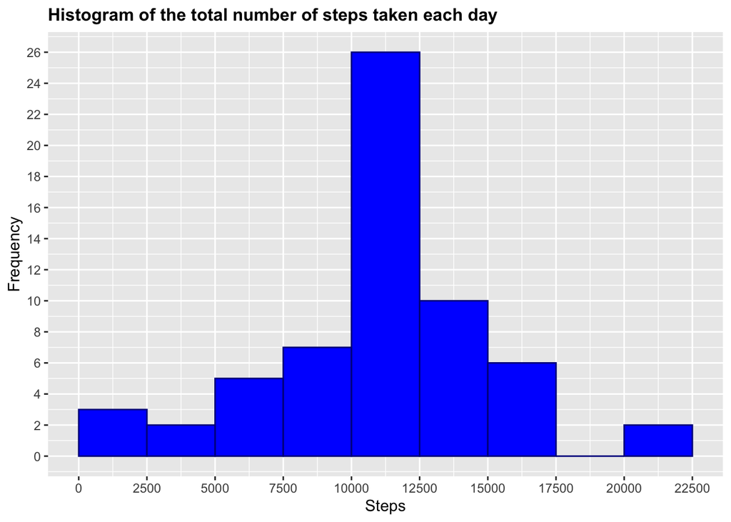

```r
Total.steps.new <- aggregate(activity.new$steps, list(activity.new$date), FUN=sum)
colnames(Total.steps.new) <- c("date", "steps")

ggplot(Total.steps.new, aes(steps)) +
  geom_histogram(boundary=0, binwidth=2500, col="darkblue", fill="blue") +
  ggtitle("Histogram of the total number of steps taken each day") +
  xlab("Steps") +
  ylab("Frequency") +
  theme(plot.title = element_text(face="bold", size=12)) +
  scale_x_continuous(breaks=seq(0,25000,2500)) +
  scale_y_continuous(breaks=seq(0,28,2))
```

### Calculate and report the mean and median total number of steps taken per day

```r
# Mean
mean(Total.steps.new$steps, na.rm=TRUE)
```

```
## [1] 10766.19
```

```r
# Median
median(Total.steps.new$steps, na.rm=TRUE)
```

```
## [1] 10766.19
```

## Are there differences in activity patterns between weekdays and weekends?

1. Create a new factor variable in the dataset with two levels – “weekday” and “weekend” indicating whether a given date is a weekday or weekend day.
2. Make a panel plot containing a time series plot (i.e. type = “l”) of the 5-minute interval (x-axis) and the average number of steps taken, averaged across all weekday days or weekend days (y-axis). See the README file in the GitHub repository to see an example of what this plot should look like using simulated data.

### New factor variable indicating whether a given date is a weekday or weekend day

```r
activity.new$date <- as.Date(strptime(activity.new$date, format="%Y-%m-%d"))

activity.new$weekday <- weekdays(activity.new$date)

activity.new$day.type <- ifelse(activity.new$weekday=='Samstag' | activity.new$weekday=='Sonntag', 'weekend','weekday')
```

### Panel plot

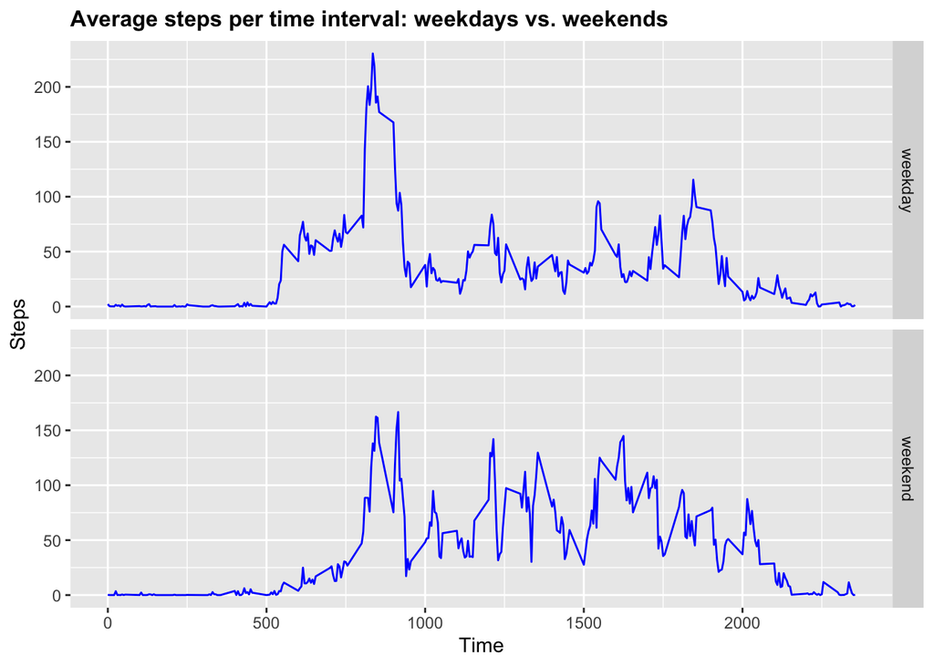

```r
Avg.steps.new <- aggregate(activity.new$steps, by=list(activity.new$interval, activity.new$day.type), FUN=mean, na.rm=TRUE)
colnames(Avg.steps.new) <- c("interval", "day.type", "mean")

ggplot(Avg.steps.new, aes(interval, mean)) +
  geom_line(col="blue") +
  ggtitle("Average steps per time interval: weekdays vs. weekends") +
  xlab("Time") +
  ylab("Steps") +
  theme(plot.title = element_text(face="bold", size=12)) +
  facet_grid(day.type ~ .)
```